# Cyclistic

Liliana

2025-07-10

# Cyclistic

## Escenario

Eres un analista de datos júnior que trabaja en el equipo de analistas de marketing de Cyclistic, una empresa de bicicletas compartidas de Chicago. La directora de marketing cree que el éxito futuro de la empresa depende de maximizar la cantidad de membresías anuales. Por lo tanto, tu equipo quiere entender qué diferencias existen en el uso de las bicicletas Cyclistic entre los ciclistas ocasionales y los miembros anuales. A través de estos conocimientos, tu equipo diseñará una nueva estrategia de marketing para convertir a los ciclistas ocasionales en miembros anuales. Sin embargo, antes de eso, los ejecutivos de Cyclistic deben aprobar tus recomendaciones; por eso, debes respaldar tu propuesta con una visión convincente de los datos y visualizaciones profesionales de los mismos.

## Tarea empresarial

La tarea empresarial se centra en utilizar el análisis de datos para entender el comportamiento de los usuarios y guiar una estrategia de marketing que convierta a ciclistas ocasionales en miembros anuales, asegurando el crecimiento sostenible de Cyclistic.

## Fuentes de datos utilizadas

https://divvy-tripdata.s3.amazonaws.com/index.html

Serán utilizados los datos históricos de los viajes de Cyclistic (una empresa ficticia) proporcionados por Motivate International Inc. Estos son datos públicos y pertinentes para realizar este análisis.

No hay problemas con la credibilidad de estos datos, pues son datos proporcionados de una sola fuente confiable, son originales, entendibles, y actuales. Los datos han sido obtenidos bajo una licencia, respecto a la privacidad los datos han sido tratados para evitar conectar con los datos personales de los usuarios.

## Primera visualización de los datos

```r
#install.packages("tidyverse")
#install.packages("ggrepel")
#install.packages("lubridate")
#install.packages("hms")
```

```r
library(tidyverse)
library(ggrepel)
library(lubridate)
library(hms)
library(readr)
```

Explorando cada archivo descargado (correspondientes a mayo 2024 a abril 2025), cada uno correspondiente a un mes, vemos que los datos están organizados por mes, en tablas donde los nombres de las columnas son: “ride_id”, “rideable_type”, “started_at”, “ended_at”, “start_station_name”, “start_station_id”, “end_station_name”, “end_station_id”, “start_lat”, “start_lng”, “end_lat”, “end_lng”, “member_casual”. Todas las columnas coinciden en tipo de dato con las de los otros meses, por lo que podemos unir estos datos.

Para hacer la primera visualización de los datos, cargarémos los datos descargados y los uniremos en un solo archivo para verificar la integridad de los datos.

```r
# Crear una lista para almacenar los datos temporales
datos_combinados <- list()

# Vector con los meses (asumiendo que son consecutivos)
meses24 <- sprintf("%02d", 5:12) # Formato 01, 02, ..., 12

# Año de los datos 2024
anio <- "2024"

for (mes in meses24) {
  # Construir el nombre del archivo
  nombre_archivo <- paste0("Datos/", anio, mes, "-divvy-tripdata.csv")

  # Cargar el archivo
  datos_mes <- read_csv(nombre_archivo)

  # Almacenar en la lista
  datos_combinados[[mes]] <- datos_mes
}
# Vector con los meses (asumiendo que son consecutivos)
meses25 <- sprintf("%02d", 1:4) # Formato 01, 02, ..., 12

# Año de los datos 2025
anio <- "2025"

for (mes in meses25) {
  # Construir el nombre del archivo
  nombre_archivo <- paste0("Datos/", anio, mes, "-divvy-tripdata.csv")

  # Cargar el archivo
  datos_mes <- read_csv(nombre_archivo)

  # Almacenar en la lista
  datos_combinados[[mes]] <- datos_mes
}
# Combinar todos los data frames en uno solo
datos <- bind_rows(datos_combinados)

# Opcional: guardar el archivo combinado
write_csv(datos, "Datos/052024_042025.csv")
```

Cargamos el archivo generado

```r
datos <- read_csv("Datos/052024_042025.csv")
```

Realizamos un exploración de los datos

```r
head(datos)
```

```
## # A tibble: 6 × 13
##   ride_id          rideable_type started_at          ended_at
##   <chr>            <chr>         <dttm>              <dttm>
## 1 7D9F0CE9EC2A1297 classic_bike  2024-05-25 15:52:42 2024-05-25 16:11:50
## 2 02EC47687411416F classic_bike  2024-05-14 15:11:51 2024-05-14 15:22:00
## 3 101370FB2D3402BE classic_bike  2024-05-30 17:46:04 2024-05-30 18:09:16
## 4 E97E396331ED6913 electric_bike 2024-05-17 20:21:54 2024-05-17 20:40:32
## 5 674EDE311C543165 classic_bike  2024-05-22 18:52:20 2024-05-22 18:59:04
## 6 2E3EA4C19F0341A6 electric_bike 2024-05-25 19:32:12 2024-05-25 19:36:17
## # ℹ 9 more variables: start_station_name <chr>, start_station_id <chr>,
## #   end_station_name <chr>, end_station_id <chr>, start_lat <dbl>,
## #   start_lng <dbl>, end_lat <dbl>, end_lng <dbl>, member_casual <chr>
```

```r
# Estructura
str(datos)
```

```
## spc_tbl_ [5,735,884 × 13] (S3: spec_tbl_df/tbl_df/tbl/data.frame)
##  $ ride_id           : chr [1:5735884] "7D9F0CE9EC2A1297" "02EC47687411416F" "101370FB2D3402BE" "E97E396331ED6913" ...
##  $ rideable_type     : chr [1:5735884] "classic_bike" "classic_bike" "classic_bike" "electric_bike" ...
##  $ started_at        : POSIXct[1:5735884], format: "2024-05-25 15:52:42" "2024-05-14 15:11:51" ...
##  $ ended_at          : POSIXct[1:5735884], format: "2024-05-25 16:11:50" "2024-05-14 15:22:00" ...
##  $ start_station_name: chr [1:5735884] "Streeter Dr & Grand Ave" "Sheridan Rd & Greenleaf Ave" "Streeter Dr & Grand Ave" "Streeter Dr & Grand Ave" ...
##  $ start_station_id  : chr [1:5735884] "13022" "KA1504000159" "13022" "13022" ...
##  $ end_station_name  : chr [1:5735884] "Clark St & Elm St" "Sheridan Rd & Loyola Ave" "Wabash Ave & 9th St" "Sheffield Ave & Wellington Ave" ...
##  $ end_station_id    : chr [1:5735884] "TA1307000039" "RP-009" "TA1309000010" "TA1307000052" ...
##  $ start_lat         : num [1:5735884] 41.9 42 41.9 41.9 41.9 ...
##  $ start_lng         : num [1:5735884] -87.6 -87.7 -87.6 -87.6 -87.6 ...
##  $ end_lat           : num [1:5735884] 41.9 42 41.9 41.9 41.9 ...
##  $ end_lng           : num [1:5735884] -87.6 -87.7 -87.6 -87.7 -87.6 ...
##  $ member_casual     : chr [1:5735884] "casual" "casual" "member" "member" ...
##  - attr(*, "spec")=
##   .. cols(
##   ..   ride_id = col_character(),
##   ..   rideable_type = col_character(),
##   ..   started_at = col_datetime(format = ""),
##   ..   ended_at = col_datetime(format = ""),
##   ..   start_station_name = col_character(),
##   ..   start_station_id = col_character(),
##   ..   end_station_name = col_character(),
##   ..   end_station_id = col_character(),
##   ..   start_lat = col_double(),
##   ..   start_lng = col_double(),
##   ..   end_lat = col_double(),
##   ..   end_lng = col_double(),
##   ..   member_casual = col_character()
##   .. )
##  - attr(*, "problems")=<externalptr>
```

```r
# Variables contenidas
colnames(datos)
```

```
##  [1] "ride_id"            "rideable_type"      "started_at"
##  [4] "ended_at"           "start_station_name" "start_station_id"
##  [7] "end_station_name"   "end_station_id"     "start_lat"
## [10] "start_lng"          "end_lat"            "end_lng"
## [13] "member_casual"
```

```r
# Número de datos
nrow(datos)
```

```
## [1] 5735884
```

Verificamos la integridad de los datos

```r
colSums(is.na(datos))
```

```
##            ride_id      rideable_type         started_at           ended_at
##                  0                  0                  0                  0
## start_station_name   start_station_id   end_station_name     end_station_id
##            1087633            1087633            1116035            1116035
##          start_lat          start_lng            end_lat            end_lng
##                  0                  0               6399               6399
##      member_casual
##                  0
```

Observamos que existen datos que están incompletos, ya que no cuentan con el nombre de la estación de inicio y su id, la estación final y su id, así como las posiciónes de longitud y latitud de los puntos finales. Sin embargo las variables que trabajaremos en este análisis se encuentran completas, por lo que concluimos que los datos cumplen con la integridad necesaria para continuar con el análisis.

## Limpieza / Procesamiento de los datos

(Por cuestiones de recursos, el procesamiento de los datos se realizará por archivo para unirse al final)

```r
#Función para cargar cada archivo descargado y procesarlo
#para generar un nuevo archivo de datos ya formateados
formatear_mes <- function(mes, anio){

  nombre_archivo_original <- paste0("Datos/", anio, mes, "-divvy-tripdata.csv")

  if(!file.exists(nombre_archivo_original)) {
    message(paste("Archivo no encontrado:", nombre_archivo_original))
    return()
  }

  message(paste("Procesando:", anio, "-", mes))

  datos_mes <- read_csv(nombre_archivo_original)

  nuevos_datos <- datos_mes %>%
    mutate(
      ride_length = hms::as_hms(difftime(ended_at, started_at, units = "secs")),
      date = as.Date(started_at),
      month = format(as.Date(started_at), "%m"),
      day_of_week = wday(started_at)
    )%>%
    select(-c(end_station_id,start_station_id,start_lat, start_lng, end_lat, end_lng))

  nuevos_datos_v2 <- nuevos_datos[!(nuevos_datos$ride_length<0),]

  str(nuevos_datos_v2)

  nombre_archivo_nuevo <- paste0("Datos/DatosFormateados/", anio, mes, ".csv")
  write_csv(nuevos_datos_v2, nombre_archivo_nuevo)

}


formatea_datos <- function(mes_inicio, anio_inicio, mes_final, anio_final){

  # Recibe los datos numéricos enteros del periodo de tiempo que se va a
  # procesar, identifica si se trata de un periodo durante el mismo año o
  # si se trata de años distintos, y formatea mes por mes.


  # Verificar si es el mismo año
  if(anio_inicio == anio_final) {
    meses <- mes_inicio:mes_final
    for(mes in meses) {
      mes <- sprintf("%02d", mes)
      formatear_mes(mes, anio_inicio)
    }
    return()
  }

  # Procesar múltiples años
  for(anio in anio_inicio:anio_final) {
    # Determinar los meses para cada año
    if(anio == anio_inicio) {
      meses <- mes_inicio:12
    } else if(anio == anio_final) {
      meses <- 1:mes_final
    } else {
      meses <- 1:12
    }

    for(mes in meses) {
      mes <- sprintf("%02d", mes)
      formatear_mes(mes, anio)
    }
  }
}

formatea_datos(5,2024,4,2025)
```

```
## Procesando: 2024 - 05
```

```
## tibble [609,417 × 11] (S3: tbl_df/tbl/data.frame)
##  $ ride_id           : chr [1:609417] "7D9F0CE9EC2A1297" "02EC47687411416F" "101370FB2D3402BE" "E97E396331ED6913" ...
##  $ rideable_type     : chr [1:609417] "classic_bike" "classic_bike" "classic_bike" "electric_bike" ...
##  $ started_at        : POSIXct[1:609417], format: "2024-05-25 15:52:42" "2024-05-14 15:11:51" ...
##  $ ended_at          : POSIXct[1:609417], format: "2024-05-25 16:11:50" "2024-05-14 15:22:00" ...
##  $ start_station_name: chr [1:609417] "Streeter Dr & Grand Ave" "Sheridan Rd & Greenleaf Ave" "Streeter Dr & Grand Ave" "Streeter Dr & Grand Ave" ...
##  $ end_station_name  : chr [1:609417] "Clark St & Elm St" "Sheridan Rd & Loyola Ave" "Wabash Ave & 9th St" "Sheffield Ave & Wellington Ave" ...
##  $ member_casual     : chr [1:609417] "casual" "casual" "member" "member" ...
##  $ ride_length       : 'hms' num [1:609417] 00:19:08 00:10:09 00:23:12 00:18:38 ...
##   ..- attr(*, "units")= chr "secs"
##  $ date              : Date[1:609417], format: "2024-05-25" "2024-05-14" ...
##  $ month             : chr [1:609417] "05" "05" "05" "05" ...
##  $ day_of_week       : num [1:609417] 7 3 5 6 4 7 6 1 1 2 ...
```

```
## Procesando: 2024 - 06
```

```
## tibble [710,721 × 11] (S3: tbl_df/tbl/data.frame)
##  $ ride_id           : chr [1:710721] "CDE6023BE6B11D2F" "462B48CD292B6A18" "9CFB6A858D23ABF7" "6365EFEB64231153" ...
##  $ rideable_type     : chr [1:710721] "electric_bike" "electric_bike" "electric_bike" "electric_bike" ...
##  $ started_at        : POSIXct[1:710721], format: "2024-06-11 17:20:06" "2024-06-11 17:19:21" ...
##  $ ended_at          : POSIXct[1:710721], format: "2024-06-11 17:21:39" "2024-06-11 17:19:36" ...
##  $ start_station_name: chr [1:710721] NA NA NA NA ...
##  $ end_station_name  : chr [1:710721] NA NA NA NA ...
##  $ member_casual     : chr [1:710721] "casual" "casual" "casual" "casual" ...
##  $ ride_length       : 'hms' num [1:710721] 00:01:33.175 00:00:14.810 00:04:45.946 00:14:22.613 ...
##   ..- attr(*, "units")= chr "secs"
##  $ date              : Date[1:710721], format: "2024-06-11" "2024-06-11" ...
##  $ month             : chr [1:710721] "06" "06" "06" "06" ...
##  $ day_of_week       : num [1:710721] 3 3 3 3 3 3 3 3 3 3 ...
```

```
## Procesando: 2024 - 07
```

```
## tibble [748,962 × 11] (S3: tbl_df/tbl/data.frame)
##  $ ride_id           : chr [1:748962] "2658E319B13141F9" "B2176315168A47CE" "C2A9D33DF7EBB422" "8BFEA406DF01D8AD" ...
##  $ rideable_type     : chr [1:748962] "electric_bike" "electric_bike" "electric_bike" "electric_bike" ...
##  $ started_at        : POSIXct[1:748962], format: "2024-07-11 08:15:14" "2024-07-11 15:45:07" ...
##  $ ended_at          : POSIXct[1:748962], format: "2024-07-11 08:17:56" "2024-07-11 16:06:04" ...
##  $ start_station_name: chr [1:748962] NA NA NA NA ...
##  $ end_station_name  : chr [1:748962] NA NA NA NA ...
##  $ member_casual     : chr [1:748962] "casual" "casual" "casual" "casual" ...
##  $ ride_length       : 'hms' num [1:748962] 00:02:41.551 00:20:56.392 00:03:17.045 00:28:04.800 ...
##   ..- attr(*, "units")= chr "secs"
##  $ date              : Date[1:748962], format: "2024-07-11" "2024-07-11" ...
##  $ month             : chr [1:748962] "07" "07" "07" "07" ...
##  $ day_of_week       : num [1:748962] 5 5 5 5 5 5 5 5 5 4 ...
```

```
## Procesando: 2024 - 08
```

```
## tibble [755,639 × 11] (S3: tbl_df/tbl/data.frame)
##  $ ride_id           : chr [1:755639] "BAA154388A869E64" "8752245932EFF67A" "44DDF9F57A9A161F" "44AAAF069B0C78C3" ...
##  $ rideable_type     : chr [1:755639] "classic_bike" "electric_bike" "classic_bike" "electric_bike" ...
##  $ started_at        : POSIXct[1:755639], format: "2024-08-02 13:35:14" "2024-08-02 15:33:13" ...
##  $ ended_at          : POSIXct[1:755639], format: "2024-08-02 13:48:24" "2024-08-02 15:55:23" ...
##  $ start_station_name: chr [1:755639] "State St & Randolph St" "Franklin St & Monroe St" "Franklin St & Monroe St" "Clark St & Elm St" ...
##  $ end_station_name  : chr [1:755639] "Wabash Ave & 9th St" "Damen Ave & Cortland St" "Clark St & Elm St" "McClurg Ct & Ohio St" ...
##  $ member_casual     : chr [1:755639] "member" "member" "member" "member" ...
##  $ ride_length       : 'hms' num [1:755639] 00:13:10.023 00:22:09.900 00:13:45.876 00:09:21.414 ...
##   ..- attr(*, "units")= chr "secs"
##  $ date              : Date[1:755639], format: "2024-08-02" "2024-08-02" ...
##  $ month             : chr [1:755639] "08" "08" "08" "08" ...
##  $ day_of_week       : num [1:755639] 6 6 6 2 7 7 4 3 3 3 ...
```

```
## Procesando: 2024 - 09
```

```
## tibble [821,276 × 11] (S3: tbl_df/tbl/data.frame)
##  $ ride_id           : chr [1:821276] "31D38723D5A8665A" "67CB39987F4E895B" "DA61204FD26EC681" "06F160D46AF235DD" ...
##  $ rideable_type     : chr [1:821276] "electric_bike" "electric_bike" "electric_bike" "electric_bike" ...
##  $ started_at        : POSIXct[1:821276], format: "2024-09-26 15:30:58" "2024-09-26 15:31:32" ...
##  $ ended_at          : POSIXct[1:821276], format: "2024-09-26 15:30:59" "2024-09-26 15:53:13" ...
##  $ start_station_name: chr [1:821276] NA NA NA NA ...
##  $ end_station_name  : chr [1:821276] NA NA NA NA ...
##  $ member_casual     : chr [1:821276] "member" "member" "member" "member" ...
##  $ ride_length       : 'hms' num [1:821276] 00:00:01.287 00:21:40.972 00:01:52.394 00:19:47.024 ...
##   ..- attr(*, "units")= chr "secs"
##  $ date              : Date[1:821276], format: "2024-09-26" "2024-09-26" ...
##  $ month             : chr [1:821276] "09" "09" "09" "09" ...
##  $ day_of_week       : num [1:821276] 5 5 5 5 3 4 4 4 7 7 ...
```

```
## Procesando: 2024 - 10
```

```
## tibble [616,281 × 11] (S3: tbl_df/tbl/data.frame)
##  $ ride_id           : chr [1:616281] "4422E707103AA4FF" "19DB722B44CBE82F" "20AE2509FD68C939" "D0F17580AB9515A9" ...
##  $ rideable_type     : chr [1:616281] "electric_bike" "electric_bike" "electric_bike" "electric_bike" ...
##  $ started_at        : POSIXct[1:616281], format: "2024-10-14 03:26:04" "2024-10-13 19:33:38" ...
##  $ ended_at          : POSIXct[1:616281], format: "2024-10-14 03:32:56" "2024-10-13 19:39:04" ...
##  $ start_station_name: chr [1:616281] NA NA NA NA ...
##  $ end_station_name  : chr [1:616281] NA NA NA NA ...
##  $ member_casual     : chr [1:616281] "member" "member" "member" "member" ...
##  $ ride_length       : 'hms' num [1:616281] 00:06:52.452 00:05:25.564 00:07:13.817 00:11:58.455 ...
##   ..- attr(*, "units")= chr "secs"
##  $ date              : Date[1:616281], format: "2024-10-14" "2024-10-13" ...
##  $ month             : chr [1:616281] "10" "10" "10" "10" ...
##  $ day_of_week       : num [1:616281] 2 1 1 2 1 2 2 6 7 7 ...
```

```
## Procesando: 2024 - 11
```

```
## tibble [335,032 × 11] (S3: tbl_df/tbl/data.frame)
##  $ ride_id           : chr [1:335032] "578DDD7CE1771FFA" "78B141C50102ABA6" "1E794CF36394E2D7" "E5DD2CAB58D73F98" ...
##  $ rideable_type     : chr [1:335032] "classic_bike" "classic_bike" "classic_bike" "classic_bike" ...
##  $ started_at        : POSIXct[1:335032], format: "2024-11-07 19:21:58" "2024-11-22 14:49:00" ...
##  $ ended_at          : POSIXct[1:335032], format: "2024-11-07 19:28:57" "2024-11-22 14:56:15" ...
##  $ start_station_name: chr [1:335032] "Walsh Park" "Walsh Park" "Walsh Park" "Clark St & Elm St" ...
##  $ end_station_name  : chr [1:335032] "Leavitt St & North Ave" "Leavitt St & Armitage Ave" "Damen Ave & Cortland St" "Clark St & Drummond Pl" ...
##  $ member_casual     : chr [1:335032] "member" "member" "member" "member" ...
##  $ ride_length       : 'hms' num [1:335032] 00:06:59.095 00:07:15.044 00:04:33.242 00:14:18.430 ...
##   ..- attr(*, "units")= chr "secs"
##  $ date              : Date[1:335032], format: "2024-11-07" "2024-11-22" ...
##  $ month             : chr [1:335032] "11" "11" "11" "11" ...
##  $ day_of_week       : num [1:335032] 5 6 6 1 2 1 4 2 2 6 ...
```

```
## Procesando: 2024 - 12
```

```
## tibble [178,372 × 11] (S3: tbl_df/tbl/data.frame)
##  $ ride_id           : chr [1:178372] "6C960DEB4F78854E" "C0913EEB2834E7A2" "848A37DD4723078A" "3FA09C762ECB48BD" ...
##  $ rideable_type     : chr [1:178372] "electric_bike" "classic_bike" "classic_bike" "electric_bike" ...
##  $ started_at        : POSIXct[1:178372], format: "2024-12-31 01:38:35" "2024-12-21 18:41:26" ...
##  $ ended_at          : POSIXct[1:178372], format: "2024-12-31 01:48:45" "2024-12-21 18:47:33" ...
##  $ start_station_name: chr [1:178372] "Halsted St & Roscoe St" "Clark St & Wellington Ave" "Sheridan Rd & Montrose Ave" "Aberdeen St & Jackson Blvd" ...
##  $ end_station_name  : chr [1:178372] "Clark St & Winnemac Ave" "Halsted St & Roscoe St" "Broadway & Barry Ave" "Green St & Randolph St*" ...
##  $ member_casual     : chr [1:178372] "member" "member" "member" "member" ...
##  $ ride_length       : 'hms' num [1:178372] 00:10:10.757 00:06:07.393 00:11:43.430 00:03:26.604 ...
##   ..- attr(*, "units")= chr "secs"
##  $ date              : Date[1:178372], format: "2024-12-31" "2024-12-21" ...
##  $ month             : chr [1:178372] "12" "12" "12" "12" ...
##  $ day_of_week       : num [1:178372] 3 7 7 5 6 1 1 2 5 7 ...
```

```
## Procesando: 2025 - 01
```

```
## tibble [138,689 × 11] (S3: tbl_df/tbl/data.frame)
##  $ ride_id           : chr [1:138689] "7569BC890583FCD7" "013609308856B7FC" "EACACD3CE0607C0D" "EAA2485BA64710D3" ...
##  $ rideable_type     : chr [1:138689] "classic_bike" "electric_bike" "classic_bike" "classic_bike" ...
##  $ started_at        : POSIXct[1:138689], format: "2025-01-21 17:23:54" "2025-01-11 15:44:06" ...
##  $ ended_at          : POSIXct[1:138689], format: "2025-01-21 17:37:52" "2025-01-11 15:49:11" ...
##  $ start_station_name: chr [1:138689] "Wacker Dr & Washington St" "Halsted St & Wrightwood Ave" "Southport Ave & Waveland Ave" "Southport Ave & Waveland Ave" ...
##  $ end_station_name  : chr [1:138689] "McClurg Ct & Ohio St" "Racine Ave & Belmont Ave" "Broadway & Cornelia Ave" "Southport Ave & Roscoe St" ...
##  $ member_casual     : chr [1:138689] "member" "member" "member" "member" ...
##  $ ride_length       : 'hms' num [1:138689] 00:13:57.477 00:05:04.344 00:11:35.500 00:03:34.233 ...
##   ..- attr(*, "units")= chr "secs"
##  $ date              : Date[1:138689], format: "2025-01-21" "2025-01-11" ...
##  $ month             : chr [1:138689] "01" "01" "01" "01" ...
##  $ day_of_week       : num [1:138689] 3 7 5 5 5 5 1 6 2 4 ...
```

```
## Procesando: 2025 - 02
```

```
## tibble [151,880 × 11] (S3: tbl_df/tbl/data.frame)
##  $ ride_id           : chr [1:151880] "A246CA24873F7C5C" "303C0906F3F068AE" "A0F65F3531F1FB2B" "CE663C815B6A6D73" ...
##  $ rideable_type     : chr [1:151880] "classic_bike" "classic_bike" "electric_bike" "electric_bike" ...
##  $ started_at        : POSIXct[1:151880], format: "2025-02-25 21:21:21" "2025-02-08 14:55:13" ...
##  $ ended_at          : POSIXct[1:151880], format: "2025-02-25 21:30:09" "2025-02-08 15:13:39" ...
##  $ start_station_name: chr [1:151880] "Michigan Ave & Lake St" "Ogden Ave & Race Ave" "Michigan Ave & Lake St" "Ogden Ave & Race Ave" ...
##  $ end_station_name  : chr [1:151880] "Clark St & Elm St" "Clark St & Elm St" "Wabash Ave & 9th St" "Clark St & Elm St" ...
##  $ member_casual     : chr [1:151880] "member" "member" "casual" "casual" ...
##  $ ride_length       : 'hms' num [1:151880] 00:08:48.770 00:18:26.397 00:05:25.158 00:33:50.366 ...
##   ..- attr(*, "units")= chr "secs"
##  $ date              : Date[1:151880], format: "2025-02-25" "2025-02-08" ...
##  $ month             : chr [1:151880] "02" "02" "02" "02" ...
##  $ day_of_week       : num [1:151880] 3 7 2 6 2 5 4 2 3 6 ...
```

```
## Procesando: 2025 - 03
```

```
## tibble [298,155 × 11] (S3: tbl_df/tbl/data.frame)
##  $ ride_id           : chr [1:298155] "16CBE9844D401954" "1CB408029E2B5F74" "7B6A76CD0F204D08" "4F7084E3D75CDE31" ...
##  $ rideable_type     : chr [1:298155] "electric_bike" "electric_bike" "electric_bike" "electric_bike" ...
##  $ started_at        : POSIXct[1:298155], format: "2025-03-18 08:39:20" "2025-03-24 16:04:22" ...
##  $ ended_at          : POSIXct[1:298155], format: "2025-03-18 08:51:37" "2025-03-24 16:27:41" ...
##  $ start_station_name: chr [1:298155] NA NA NA NA ...
##  $ end_station_name  : chr [1:298155] "Canal St & Jackson Blvd" "Albany Ave & Bloomingdale Ave" "Albany Ave & Bloomingdale Ave" "Canal St & Jackson Blvd" ...
##  $ member_casual     : chr [1:298155] "member" "member" "member" "member" ...
##  $ ride_length       : 'hms' num [1:298155] 00:12:17.568 00:23:19.108 00:22:57.749 00:06:51.581 ...
##   ..- attr(*, "units")= chr "secs"
##  $ date              : Date[1:298155], format: "2025-03-18" "2025-03-24" ...
##  $ month             : chr [1:298155] "03" "03" "03" "03" ...
##  $ day_of_week       : num [1:298155] 3 2 2 6 6 2 3 7 5 6 ...
```

```
## Procesando: 2025 - 04
```

```
## tibble [371,341 × 11] (S3: tbl_df/tbl/data.frame)
##  $ ride_id           : chr [1:371341] "AF3863596DF9D94B" "8B38081EBE918800" "1C7F1DE826BBBC8D" "CAD23D69A79A6C3B" ...
##  $ rideable_type     : chr [1:371341] "classic_bike" "electric_bike" "electric_bike" "classic_bike" ...
##  $ started_at        : POSIXct[1:371341], format: "2025-04-27 14:29:34" "2025-04-23 17:48:51" ...
##  $ ended_at          : POSIXct[1:371341], format: "2025-04-27 14:36:23" "2025-04-23 17:59:06" ...
##  $ start_station_name: chr [1:371341] "Troy St & Elston Ave" "Wabash Ave & Adams St" "Damen Ave & Cortland St" "Clark St & Elm St" ...
##  $ end_station_name  : chr [1:371341] "Richmond St & Diversey Ave" "Green St & Madison St" "California Ave & Fletcher St" "Orleans St & Merchandise Mart Plaza" ...
##  $ member_casual     : chr [1:371341] "member" "member" "member" "member" ...
##  $ ride_length       : 'hms' num [1:371341] 00:06:48.965 00:10:14.152 00:10:09.187 00:10:01.606 ...
##   ..- attr(*, "units")= chr "secs"
##  $ date              : Date[1:371341], format: "2025-04-27" "2025-04-23" ...
##  $ month             : chr [1:371341] "04" "04" "04" "04" ...
##  $ day_of_week       : num [1:371341] 1 4 7 5 3 4 7 7 3 4 ...
```

Unimos los datos ya formateados.

```r
# Crear una lista para almacenar los datos temporales
datos_combinados <- list()

# Vector con los meses (asumiendo que son consecutivos)
meses24 <- sprintf("%02d", 5:12) # Formato 01, 02, ..., 12

# Año de los datos 2024
anio <- "2024"

for (mes in meses24) {
  # Construir el nombre del archivo
  nombre_archivo <- paste0("Datos/DatosFormateados/", anio, mes, ".csv")

  # Cargar el archivo y asegurar que month sea character
  datos_mes <- read_csv(nombre_archivo) %>%
    mutate(month = as.character(month))

  # Almacenar en la lista
  datos_combinados[[mes]] <- datos_mes
}
# Vector con los meses (asumiendo que son consecutivos)
meses25 <- sprintf("%02d", 1:4) # Formato 01, 02, ..., 12

# Año de los datos 2025
anio <- "2025"

for (mes in meses25) {
  # Construir el nombre del archivo
  nombre_archivo <- paste0("Datos/DatosFormateados/", anio, mes, ".csv")

  # Cargar el archivo y asegurar que month sea character
  datos_mes <- read_csv(nombre_archivo) %>%
    mutate(month = as.character(month))

  # Almacenar en la lista
  datos_combinados[[mes]] <- datos_mes
}
# Combinar todos los data frames en uno solo
datos <- bind_rows(datos_combinados)

# Opcional: guardar el archivo combinado
write_csv(datos, "Datos/DatosResumen/052024_042025.csv")
```

## Análisis

```r
datos_anio <- read_csv("Datos/DatosResumen/052024_042025.csv")
head(datos_anio)
```

```
## # A tibble: 6 × 11
##   ride_id          rideable_type started_at          ended_at
##   <chr>            <chr>         <dttm>              <dttm>
## 1 7D9F0CE9EC2A1297 classic_bike  2024-05-25 15:52:42 2024-05-25 16:11:50
## 2 02EC47687411416F classic_bike  2024-05-14 15:11:51 2024-05-14 15:22:00
## 3 101370FB2D3402BE classic_bike  2024-05-30 17:46:04 2024-05-30 18:09:16
## 4 E97E396331ED6913 electric_bike 2024-05-17 20:21:54 2024-05-17 20:40:32
## 5 674EDE311C543165 classic_bike  2024-05-22 18:52:20 2024-05-22 18:59:04
## 6 2E3EA4C19F0341A6 electric_bike 2024-05-25 19:32:12 2024-05-25 19:36:17
## # ℹ 7 more variables: start_station_name <chr>, end_station_name <chr>,
## #   member_casual <chr>, ride_length <time>, date <date>, month <chr>,
## #   day_of_week <dbl>
```

```r
datos_analizados <- nrow(datos_anio)
inicio_periodo <- as.Date(min(datos_anio$started_at))
termino_periodo <- as.Date(max(datos_anio$started_at))

print("Cantidad de datos analizados:")
```

```
## [1] "Cantidad de datos analizados:"
```

```r
print(datos_analizados)
```

```
## [1] 5735765
```

```r
print(paste0("Del periodo de ", inicio_periodo, " a ", termino_periodo))
```

```
## [1] "Del periodo de 2024-05-01 a 2025-04-30"
```

[figure not shown]

```r
num_viajes_vs <- datos_anio %>%
  group_by(member_casual) %>%
  summarise(
    total_rides = n(),
  )
#View(num_viajes_vs)
pct <- round(num_viajes_vs$total_rides/sum(num_viajes_vs$total_rides)*100)
etiquetas <- paste(num_viajes_vs$member_casual, pct)
etiquetas <- paste(etiquetas,"%",sep="")

ggplot(num_viajes_vs, aes(x="", y = total_rides, fill = member_casual )) +
  geom_bar(stat = "identity", width = 1) +
  coord_polar("y", start = 0) +
  geom_label_repel(
    aes(label = etiquetas, y = total_rides),
    position = position_stack(vjust = 0.5),
    size = 3,
    color = "white",
    fill = scales::alpha("gray20", 0.7),
    box.padding = 0.3,
    point.padding = 0.5,
    min.segment.length = 0.1,
    force = 0.5,
    direction = "both"
  )  +
  theme_void() +
  guides(fill = guide_legend(title = "Tipo cliente")) +
  labs(title = "Porcentaje de clientes casuales vs miembros")+
  scale_fill_viridis_d()
```

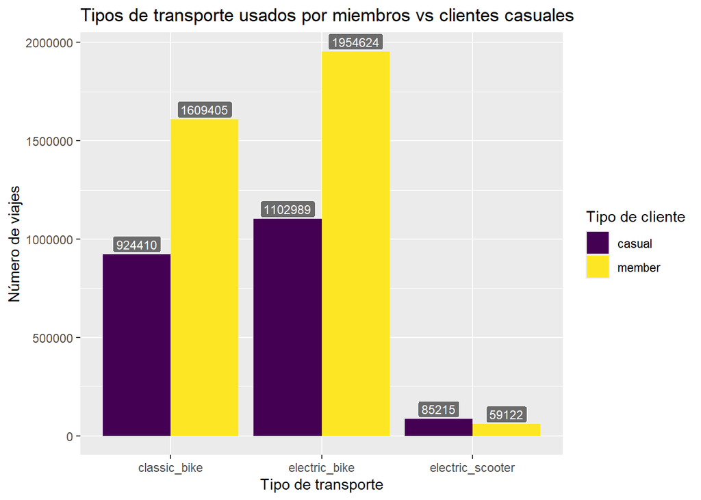

```r
ggplot(datos_anio,
       aes(x = rideable_type,
           fill = member_casual)) +
  geom_bar(position = position_dodge(width = 0.9)) +
  geom_label(
    stat = "count",
    aes(label = after_stat(count), group = member_casual),  # Crucial: agregar group
    position = position_dodge(width = 0.9),
    vjust = -0.1,
    color = "white",
    fill = scales::alpha("gray20", 0.7),
    size = 3,
    show.legend = FALSE
  ) +
  labs(x = "Tipo de transporte", y = "Número de viajes") +
  guides(fill = guide_legend(title = "Tipo de cliente")) +
  ggtitle("Tipos de transporte usados por miembros vs clientes casuales") +
  scale_fill_viridis_d() +
  ylim(0, NA)  # Ajusta automáticamente el límite superior
```

```r
rideable_type_vs <- datos_anio %>%
  group_by(member_casual, rideable_type) %>%
  summarise(
    total_rides = n(),
  )
```

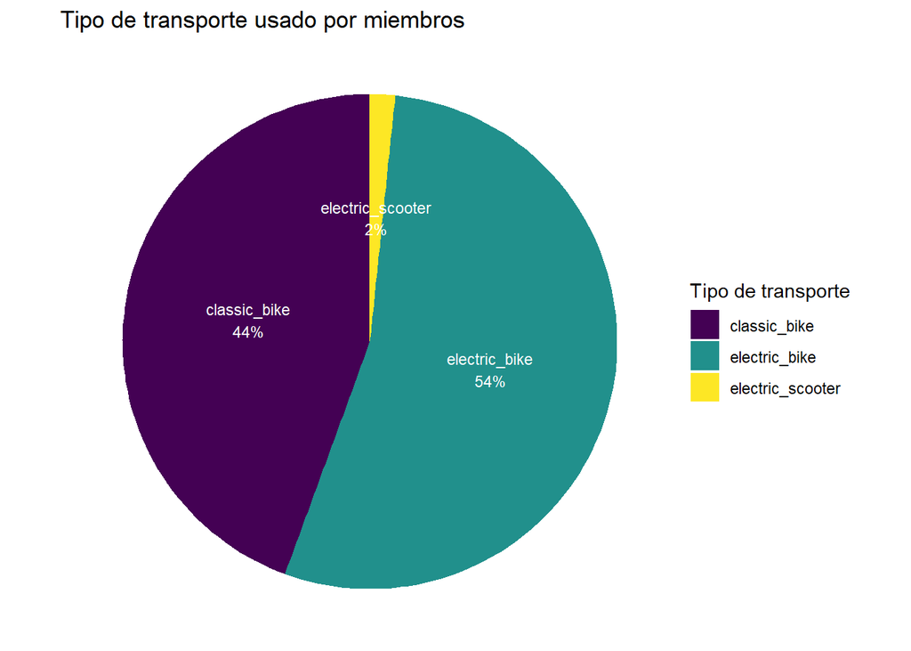

```r
miembros_type <- rideable_type_vs %>%
  filter(member_casual == 'member')

miembros_type$pct <- miembros_type$total_rides/sum(miembros_type$total_rides)*100
miembros_type$etiqueta <- ifelse(miembros_type$pct < 1,
                                 paste0(miembros_type$rideable_type, "\n", round(miembros_type$pct, 1), "%"),
                                 paste0(miembros_type$rideable_type, "\n", round(miembros_type$pct), "%"))

ggplot(miembros_type, aes(x = "", y = total_rides, fill = rideable_type)) +
  geom_bar(stat = "identity", width = 1) +
  coord_polar("y", start = 0) +
  geom_text(aes(label = etiqueta),
            position = position_stack(vjust = 0.5),
            size = 3,
            color = 'white') +
  theme_void() +
  guides(fill = guide_legend(title = "Tipo de transporte")) +
  labs(title = "Tipo de transporte usado por miembros")+
  scale_fill_viridis_d()
```

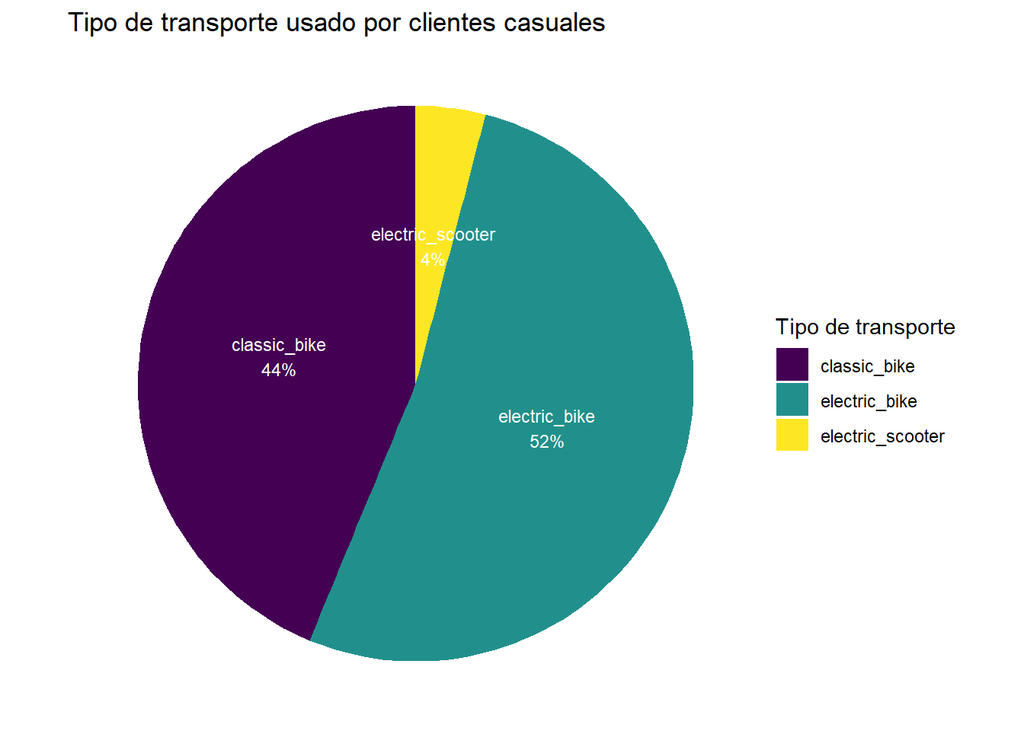

```r
casual_type <- rideable_type_vs %>%
  filter(member_casual == 'casual')

casual_type$pct <- casual_type$total_rides/sum(casual_type$total_rides)*100
casual_type$etiqueta <- ifelse(casual_type$pct < 1,
                                 paste0(casual_type$rideable_type, "\n", round(casual_type$pct, 1), "%"),
                                 paste0(casual_type$rideable_type, "\n", round(casual_type$pct), "%"))

ggplot(casual_type, aes(x = "", y = total_rides, fill = rideable_type)) +
  geom_bar(stat = "identity", width = 1) +
  coord_polar("y", start = 0) +
  geom_text(aes(label = etiqueta),
            position = position_stack(vjust = 0.5),
            size = 3,
            color = 'white')  +
  theme_void() +
  guides(fill = guide_legend(title = "Tipo de transporte")) +
  labs(title = "Tipo de transporte usado por clientes casuales")+
  scale_fill_viridis_d()
```

```r
mean_ride_length <- hms::as_hms(mean(datos_anio$ride_length))
print("El tiempo promedio de viaje es de: ")
```

```
## [1] "El tiempo promedio de viaje es de: "
```

```r
print(mean_ride_length)
```

```
## 00:16:53.006419
```

```r
print('El viaje más largo ha sido de: ')
```

```
## [1] "El viaje más largo ha sido de: "
```

```r
print(hms::as_hms(max(datos_anio$ride_length)))
```

```
## 25:59:55
```

```r
print('El viaje más corto ha sido de: ')
```

```
## [1] "El viaje más corto ha sido de: "
```

```r
print(hms::as_hms(min(datos_anio$ride_length)))
```

```
## 00:00:00
```

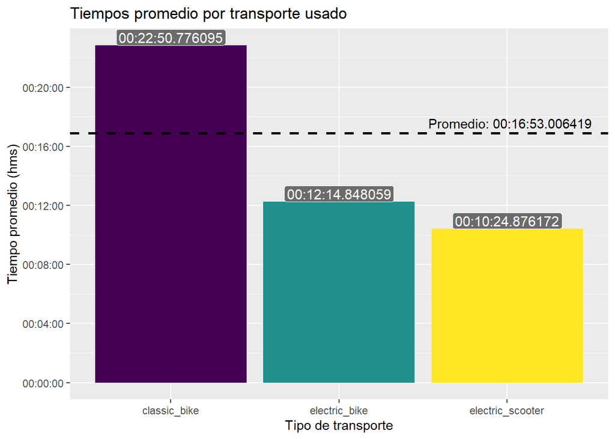

```r
ride_length_gral <- datos_anio %>%
  group_by(rideable_type) %>%
  summarise(
    total_rides = n(),
    mean_length = mean(ride_length),
    max_length = max(ride_length),
    min_length = min(ride_length)
  )

ggplot(ride_length_gral,
  aes(x = rideable_type, y = hms::as_hms(mean_length), fill = rideable_type)) +
  geom_bar(stat = "identity",position="dodge", show.legend = FALSE) +
  geom_hline(yintercept = hms::as_hms(mean_ride_length),
             color = "black",
             linetype = "dashed",
             linewidth = 1) +
  labs(x = "Tipo de transporte", y = "Tiempo promedio (hms)") +
  ggtitle("Tiempos promedio por transporte usado")+
  geom_label(stat = 'identity',
             aes(label = hms::as_hms(mean_length)),
             position = position_dodge(width = 1),
             vjust = 0,
             color = "white",
             fill = scales::alpha("gray20", 0.7),
             size = 4,
             label.padding = unit(0.15, "lines")) +
  annotate("text",
           x = Inf, y = hms::as_hms(mean_ride_length),
           label = paste("Promedio:", hms::as_hms(mean_ride_length)),
           hjust = 1.1, vjust = -0.5,
           color = "black")+
  scale_fill_viridis_d()
```

```r
ride_length_vs <- datos_anio %>%
  group_by(member_casual,rideable_type) %>%
  summarise(
    total_rides = n(),
    mean_length = hms::round_hms(hms::as_hms(mean(ride_length)), digits = 0),
    max_length = hms::as_hms(max(ride_length)),
    min_length = hms::as_hms(min(ride_length))
  )
```

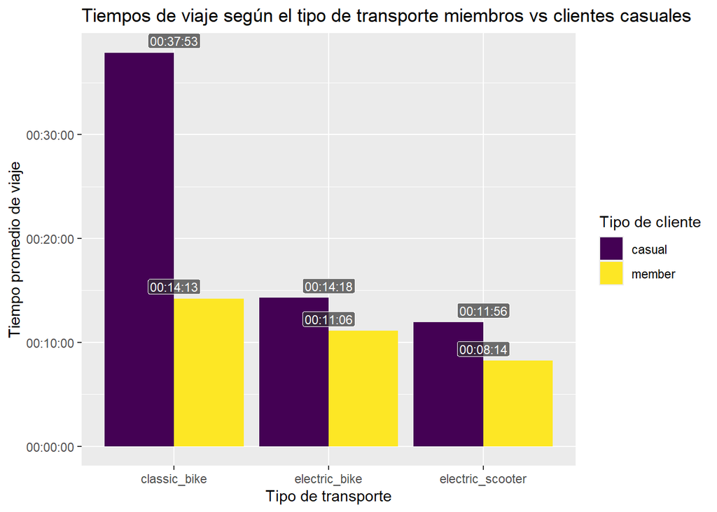

```r
#View(ride_length_vs)

ggplot(ride_length_vs,
       aes(x = rideable_type, y = mean_length,
           fill=member_casual)) +
  geom_bar(stat = "identity", position="dodge") +
  labs(x = "Tipo de transporte", y = "Tiempo promedio de viaje") +
  guides(fill = guide_legend(title = "Tipo de cliente")) +
  ggtitle("Tiempos de viaje según el tipo de transporte miembros vs clientes casuales")+
  geom_label(
    stat = "identity",
    aes(label = mean_length),
    position = position_dodge(width = 0.9),
    vjust = -0.3,
    color = "white",
    fill = scales::alpha("gray20", 0.7),
    size = 3,
    label.padding = unit(0.15, "lines"),
    show.legend = FALSE
  )  +
  scale_fill_viridis_d()
```

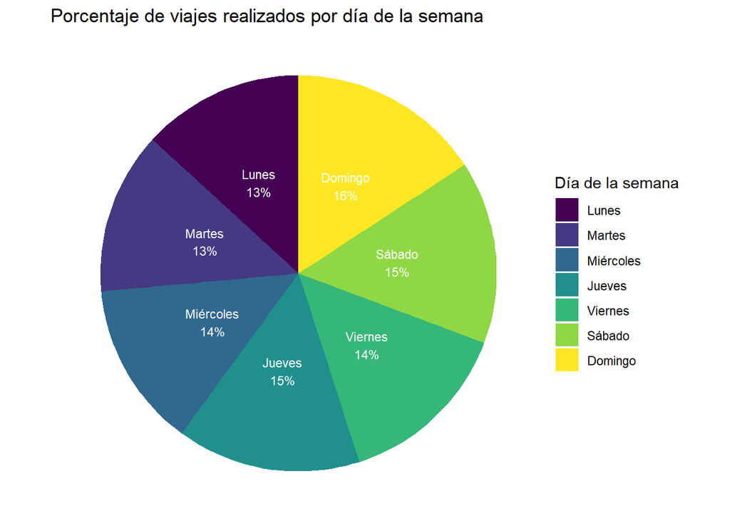

```r
concurrencia_dia_gral <- datos_anio %>%
  group_by(day_of_week) %>%
  summarise(
    total_rides = n(),
  ) %>%
  mutate(
    day_name = factor(
      day_of_week,
      levels = 1:7,
      labels = c("Lunes", "Martes", "Miércoles", "Jueves", "Viernes", "Sábado", "Domingo"),
      ordered = TRUE
    )
  )
concurrencia_dia_gral$pct <- concurrencia_dia_gral$total_rides/sum(concurrencia_dia_gral$total_rides)*100
concurrencia_dia_gral$etiqueta <- ifelse(concurrencia_dia_gral$pct < 1,
                                 paste0(concurrencia_dia_gral$day_name, "\n", round(concurrencia_dia_gral$pct, 1), "%"),
                                 paste0(concurrencia_dia_gral$day_name, "\n", round(concurrencia_dia_gral$pct), "%"))

ggplot(concurrencia_dia_gral, aes(x = "", y = total_rides, fill = day_name)) +
  geom_bar(stat = "identity", width = 1) +
  coord_polar("y", start = 0) +
  geom_text(aes(label = etiqueta),
            position = position_stack(vjust = 0.5),
            size = 3,
            color = 'white') +
  theme_void() +
  guides(fill = guide_legend(title = "Día de la semana")) +
  labs(title = "Porcentaje de viajes realizados por día de la semana")
```

```r
concurrencia_dia_vs <- datos_anio %>%
  group_by(day_of_week, member_casual) %>%
  summarise(
    total_rides = n(),
  ) %>%
  mutate(
    day_name = factor(
      day_of_week,
      levels = 1:7,
      labels = c("Lunes", "Martes", "Miércoles", "Jueves", "Viernes", "Sábado", "Domingo"),
      ordered = TRUE
    )
  )
head(concurrencia_dia_vs)
```

```
## # A tibble: 6 × 4
## # Groups:   day_of_week [3]
##   day_of_week member_casual total_rides day_name
##         <dbl> <chr>               <int> <ord>
## 1           1 casual             354296 Lunes
## 2           1 member             402920 Lunes
## 3           2 casual             244523 Martes
## 4           2 member             515691 Martes
## 5           3 casual             224093 Miércoles
## 6           3 member             550242 Miércoles
```

```r
rides_day_member <- concurrencia_dia_vs %>%
  filter(member_casual == 'member')

rides_day_member$pct <- rides_day_member$total_rides/sum(rides_day_member$total_rides)*100
rides_day_member$etiqueta <- ifelse(
  rides_day_member$pct < 1,
  paste0(rides_day_member$day_name, "\n", round(rides_day_member$pct, 1), "%"),
  paste0(rides_day_member$day_name, "\n", round(rides_day_member$pct), "%")
)

head(rides_day_member)
```

```
## # A tibble: 6 × 6
## # Groups:   day_of_week [6]
##   day_of_week member_casual total_rides day_name    pct etiqueta
##         <dbl> <chr>               <int> <ord>     <dbl> <chr>
## 1           1 member             402920 Lunes      11.1 "Lunes\n11%"
## 2           2 member             515691 Martes     14.2 "Martes\n14%"
## 3           3 member             550242 Miércoles  15.2 "Miércoles\n15%"
## 4           4 member             594390 Jueves     16.4 "Jueves\n16%"
## 5           5 member             558166 Viernes    15.4 "Viernes\n15%"
## 6           6 member             531302 Sábado     14.7 "Sábado\n15%"
```

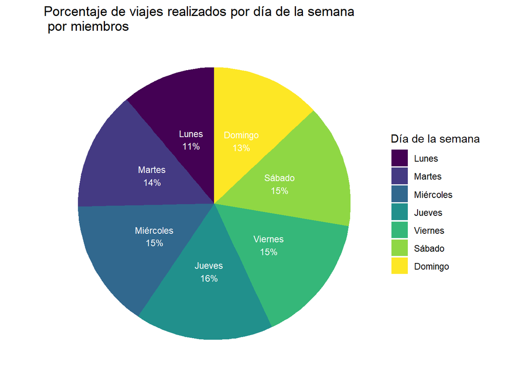

```r
ggplot(rides_day_member, aes(x = "", y = total_rides, fill = day_name)) +
  geom_bar(stat = "identity", width = 1) +
  coord_polar("y", start = 0) +
  geom_text(aes(label = etiqueta),
            position = position_stack(vjust = 0.5),
            size = 3,
            color = 'white') +
  theme_void() +
  guides(fill = guide_legend(title = "Día de la semana")) +
  labs(title = "Porcentaje de viajes realizados por día de la semana \n por miembros")
```

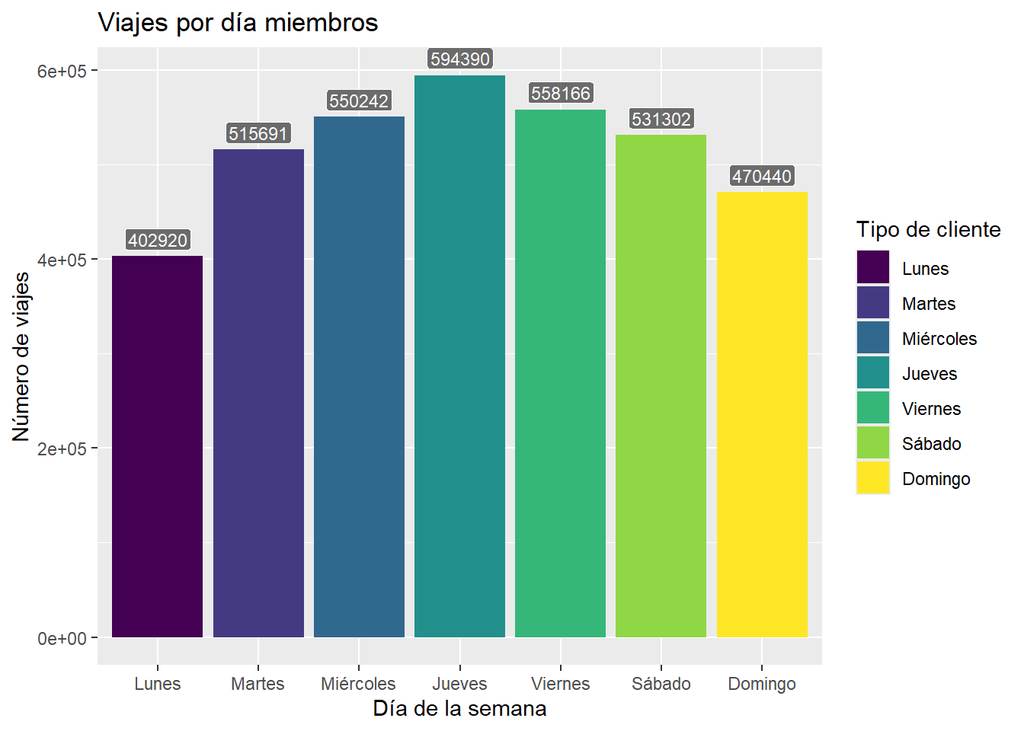

```r
ggplot(rides_day_member,
       aes(x = day_name, y = total_rides,
           fill=day_name)) +
  geom_bar(stat = "identity",  position = position_dodge(width = 0.9)) +
  labs(x = "Día de la semana", y = "Número de viajes") +
  guides(fill = guide_legend(title = "Tipo de cliente")) +
  ggtitle("Viajes por día miembros")+
  geom_label(
    stat = "identity",
    aes(label = total_rides),
    position = position_dodge(width = 0.9),
    vjust = -0.3,
    color = "white",
    fill = scales::alpha("gray20", 0.7),
    size = 3,
    label.padding = unit(0.15, "lines"),
    show.legend = FALSE
  )
```

```r
rides_day_casual <- concurrencia_dia_vs %>%
  filter(member_casual == 'casual')

rides_day_casual$pct <- rides_day_casual$total_rides/sum(rides_day_casual$total_rides)*100
rides_day_casual$etiqueta <- ifelse(rides_day_casual$pct < 1,
                                    paste0(rides_day_casual$day_name, "\n", round(rides_day_casual$pct, 1), "%"),
                                    paste0(rides_day_casual$day_name, "\n", round(rides_day_casual$pct), "%"))

head(rides_day_casual)
```

```
## # A tibble: 6 × 6
## # Groups:   day_of_week [6]
##   day_of_week member_casual total_rides day_name    pct etiqueta
##         <dbl> <chr>               <int> <ord>     <dbl> <chr>
## 1           1 casual             354296 Lunes      16.8 "Lunes\n17%"
## 2           2 casual             244523 Martes     11.6 "Martes\n12%"
## 3           3 casual             224093 Miércoles  10.6 "Miércoles\n11%"
## 4           4 casual             266645 Jueves     12.6 "Jueves\n13%"
## 5           5 casual             263459 Viernes    12.5 "Viernes\n12%"
## 6           6 casual             325427 Sábado     15.4 "Sábado\n15%"
```

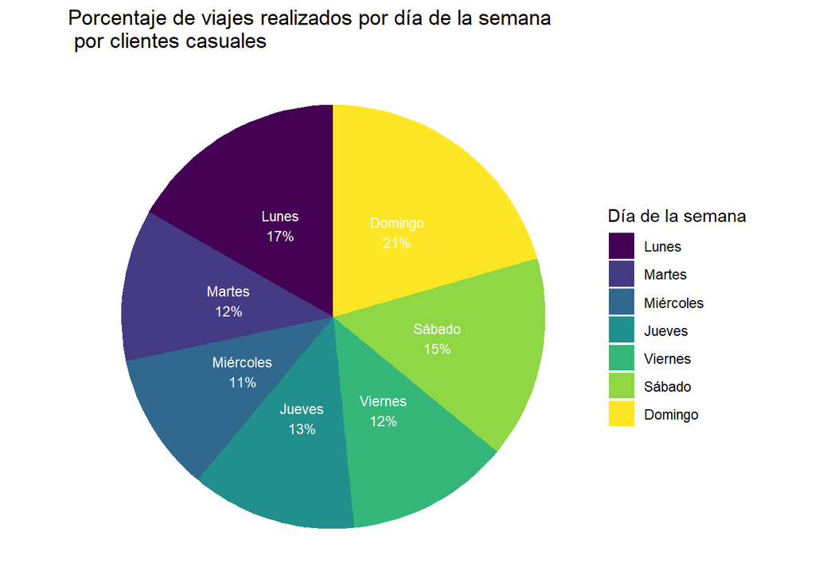

```r
ggplot(rides_day_casual, aes(x = "", y = total_rides, fill = day_name)) +
  geom_bar(stat = "identity", width = 1) +
  coord_polar("y", start = 0) +
  geom_text(aes(label = etiqueta),
            position = position_stack(vjust = 0.5),
            size = 3,
            color = 'white') +
  theme_void() +
  guides(fill = guide_legend(title = "Día de la semana")) +
  labs(title = "Porcentaje de viajes realizados por día de la semana \n por clientes casuales")
```

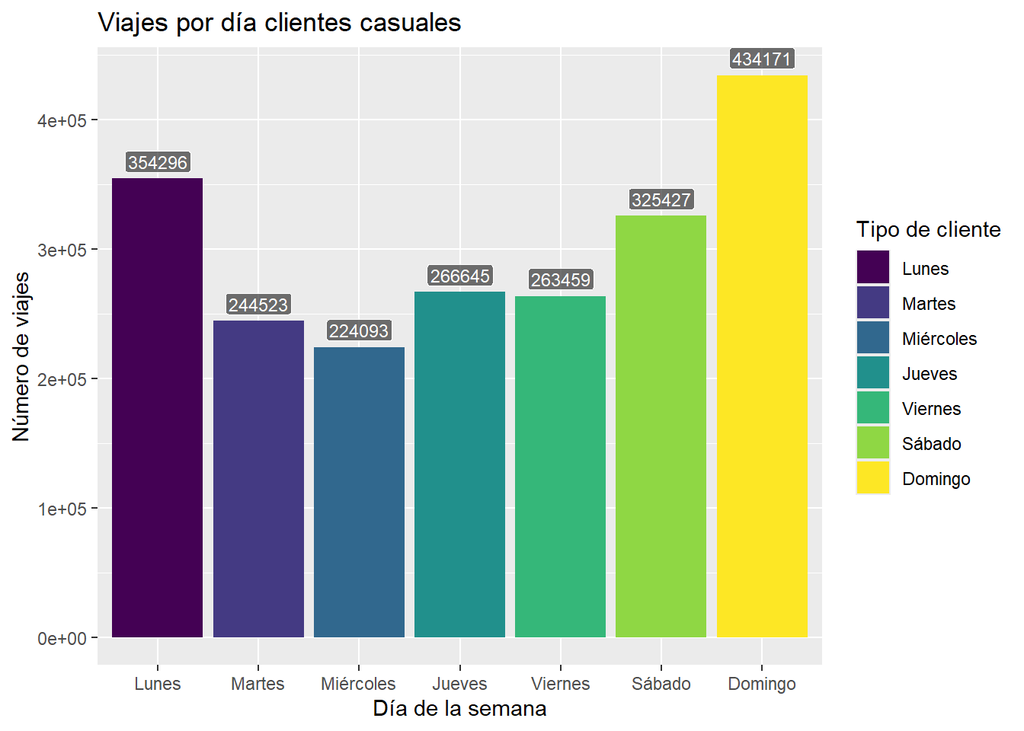

```r
ggplot(rides_day_casual,
       aes(x = day_name, y = total_rides,
           fill=day_name)) +
  geom_bar(stat = "identity", position="dodge") +
  labs(x = "Día de la semana", y = "Número de viajes") +
  guides(fill = guide_legend(title = "Tipo de cliente")) +
  ggtitle("Viajes por día clientes casuales")+
  geom_label(
    stat = "identity",
    aes(label = total_rides),
    position = position_dodge(width = 0.9),
    vjust = -0.3,
    color = "white",
    fill = scales::alpha("gray20", 0.7),
    size = 3,
    label.padding = unit(0.15, "lines"),
    show.legend = FALSE
  )
```

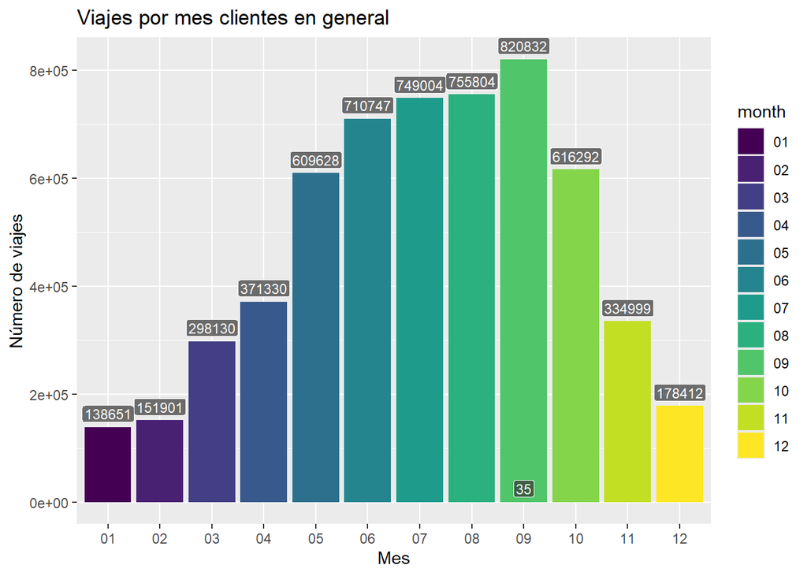

```r
concurrencia_mes_gral <- datos_anio %>%
  group_by(month) %>%
  summarise(
    total_rides = n()
  ) %>%
  mutate(month = sprintf("%02d", as.numeric(month)))

ggplot(concurrencia_mes_gral,
       aes(x = month, y = total_rides,
           fill=month)) +
  geom_bar(stat = "identity",  position = position_dodge(width = 0.9)) +
  labs(x = "Mes", y = "Número de viajes") +
  ggtitle("Viajes por mes clientes en general")+
  geom_label(
    stat = "identity",
    aes(label = total_rides),
    position = position_dodge(width = 0.9),
    vjust = -0.3,
    color = "white",
    fill = scales::alpha("gray20", 0.7),
    size = 3,
    label.padding = unit(0.15, "lines"),
    show.legend = FALSE
  )+
  scale_fill_viridis_d()
```

```r
concurrencia_mes_vs <- datos_anio %>%
  group_by(month, member_casual) %>%
  summarise(
    total_rides = n(),
  ) %>%
  mutate(month = sprintf("%02d", as.numeric(month)))
```

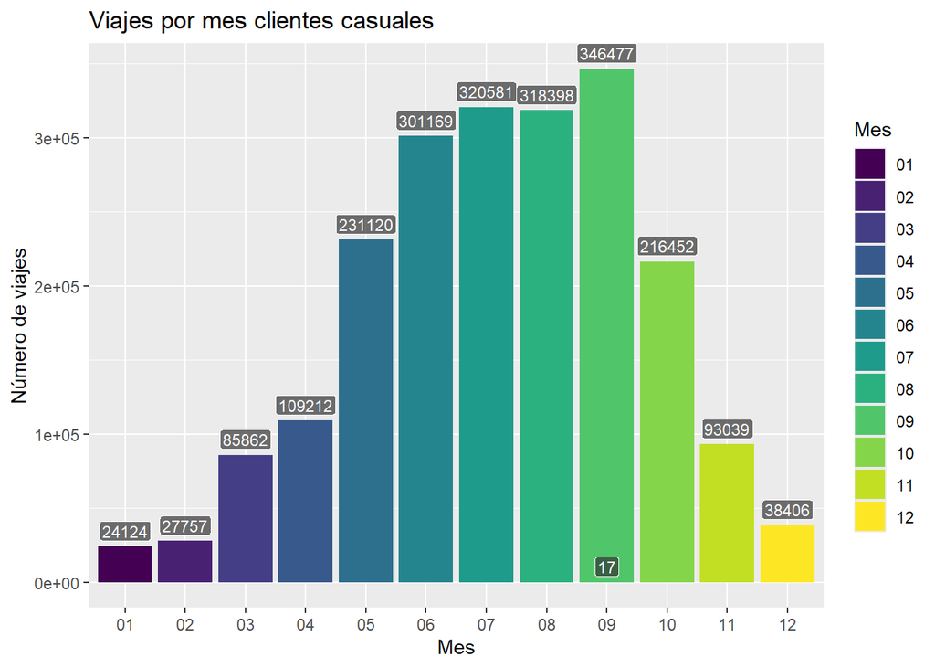

```r
rides_month_casual <- concurrencia_mes_vs %>%
  filter(member_casual == 'casual')

ggplot(rides_month_casual,
       aes(x = month, y = total_rides,
           fill=month)) +
  geom_bar(stat = "identity",  position = position_dodge(width = 0.9)) +
  labs(x = "Mes", y = "Número de viajes") +
  guides(fill = guide_legend(title = "Mes")) +
  ggtitle("Viajes por mes clientes casuales")+
  geom_label(
    stat = "identity",
    aes(label = total_rides),
    position = position_dodge(width = 0.9),
    vjust = -0.3,
    color = "white",
    fill = scales::alpha("gray20", 0.7),
    size = 3,
    label.padding = unit(0.15, "lines"),
    show.legend = FALSE
  )+
  scale_fill_viridis_d()
```

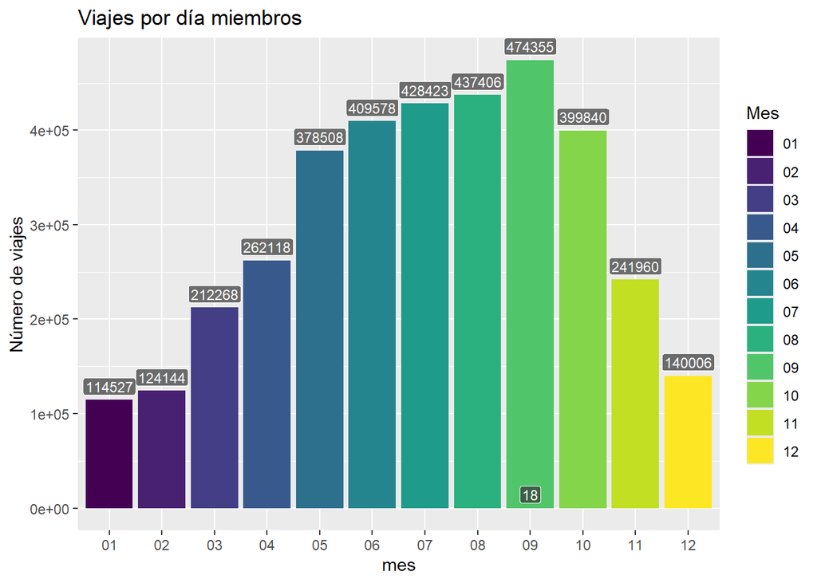

```r
rides_month_member <- concurrencia_mes_vs %>%
  filter(member_casual == 'member')

ggplot(rides_month_member,
       aes(x = month, y = total_rides,
           fill=month)) +
  geom_bar(stat = "identity",  position = position_dodge(width = 0.9)) +
  labs(x = "mes", y = "Número de viajes") +
  guides(fill = guide_legend(title = "Mes")) +
  ggtitle("Viajes por día miembros")+
  geom_label(
    stat = "identity",
    aes(label = total_rides),
    position = position_dodge(width = 0.9),
    vjust = -0.3,
    color = "white",
    fill = scales::alpha("gray20", 0.7),
    size = 3,
    label.padding = unit(0.15, "lines"),
    show.legend = FALSE
  )+
  scale_fill_viridis_d()
```

## Conclusión del Análisis

### **Recomendaciones Finales**

- **Enfoque en ahorro y conveniencia**: Destacar cómo la membresía anual reduce costos para usuarios frecuentes (como los casuales de fines de semana).
- **Promociones temporales**: Ofrecer descuentos o períodos de prueba gratuitos de la membresía durante temporadas de alta demanda recreativa (verano, festivos).
- **Personalización**: Segmentar campañas según el tipo de bicicleta preferida (ej: “¿Te gustan las bicicletas eléctricas? Con la membresía anual, tienes acceso ilimitado”).

Estas acciones, basadas en datos, podrían incrementar la conversión de ciclistas ocasionales en miembros anuales, asegurando un crecimiento sostenible para Cyclistic.